# Rent in Germany

Leonardo Özuluca

2024-01-01

## Rent in Germany

In Germany, many people complain about rising living costs, especially rising rents. Living and studying in Munich, I really feel the pain of high rent and how it affects living standards. But the real estate market is very intransparent, and I wanted precise numbers. So, I tried to understand how high rents in Germany actually are, how they developed over time, and why people complain about high rent prices. For this, I got some data from the “Statistisches Bundesamt” (Engl. Federal Statistical Office ) to analyze and visualize the development of the German rent indices. But let’s start with the source and data preparation parts.

### Sources and data integrity

In the following analysis, I used data about the German Rent index. This data is given by the “Verbraucherpreisindex” (Engl. consumer price index). The dataset that I used was the 61111-0003 dataset of the Genesis-online database from the Federal Statistical Office. Unfortunately, the current version of this dataset only contains data for the last four years (2018-2022, as I am writing this in 2023), and the older versions are not officially available anymore. Therefore, I complemented this with data from “Statista.de”. In their dataset [“Entwicklung des Wohnungsmietindex für Deutschland in den Jahren von 1995 bis 2022”](https://de.statista.com/statistik/daten/studie/70132/umfrage/mietindex-fuer-deutschland-1995-bis-2007/) They have collected the data from the “Statistisches Bundesamt” for the last approximately 25 years (1995-2022). According to them, their data is from the dataset mentioned above (61111-0003 dataset of the Genesis-online database from the Federal Statistical Office), and I verified that it is equal in the recent values with the current version of the dataset available in the genesis database. So, this is where the data about the rent index comes from.

The data for the rent load comes from a [table](https://www.destatis.de/DE/Themen/Gesellschaft-Umwelt/Wohnen/Tabellen/tabelle-wo7-mieten-einzugsjahr.html) that was published on the website of the Federal Statistical Office.

The data for the real wages comes from the 62361-0020 Dataset of the Federal Statistical Office.

Also from the Federal Statistical Office was the data about the percentages of households in Germany. It is available in their table [Haushalte nach Haushaltsgrößen im Zeitvergleich](https://www.destatis.de/DE/Themen/Gesellschaft-Umwelt/Bevoelkerung/Haushalte-Familien/Tabellen/1-3-privathaushalte-neuer-zeitvergleich.html)

For the inflation considering calculations the inflation rate of each year was publicly available in the 61111-0001 dataset of the Genesis-online database. As this data comes directly from the Federal Statistical Office, I didn’t check the data integrity further.

For everyone further interested there is a enumeration of all of the data sets / data sources at the end of this file.

### Data cleaning and preparation

The tools that I used for data cleaning and preparation were Spreadsheets (excel) and the R programming language. Excel especially for smaller datasets and easy tasks, R mostly for the big datasets as well as later in the analysis.

The given rent data was indexed with an index of 100 in 2015. I changed that so that the data starts with an index of 100 at the beginning of the data in 1995. I also calculated from each year to the next the percentage of change and joined it with the inflation data.

The inflation data was used in a spreadsheet first, where I strapped it off unnecessary header and footer information and ensured consistent formatting.

The data about the real wages was also strapped off its header and footer information to keep only the necessary data table. The real wages index was indexed with 100 at the end (2022). I changed that so that the indexing starts with an index of 100 at the beginning (2007).

The data about the rent load was only available as a table to look at, but not in machine readable format, so I transferred it into a csv file to use in the analysis.

I removed all of the formatting mistakes that I could find and searched for duplicate data mistakes, but found none. After that, I proceeded with the analysis.

## Analysis

As the actual rent price varies from house to house, depending on the location, the year it was build in, the interior design and its general features it is very difficult to compare actual rent prices. But what is instead comparable is how the same space got more or less expansive over time. This is called the rent index. Measuring the rent change from one year to the next, the German rent index went from 100 to 143.7. This means that it rose by 43.7% over the given time period. But these numbers are meaningless without context. In economics, the rising expense of something has to be seen considering inflation, the rate at which everything else (including wages) increases. Considering inflation, the German rent index actually fell by 7.7% to a value of 92.3 index points. Let’s visualize this:

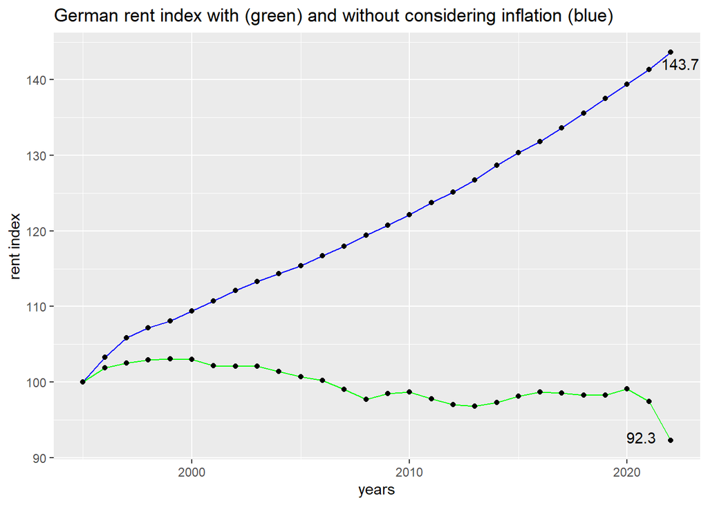

The blue line is the rent index without consideration of inflation. This is the rent data that most Germans know. The Green line represents the rise in rent compared to the general increase in everything, called inflation. Considering that, the rents in Germany actually got cheaper.

I found this very intriguing. How can it be possible that a lot of people in Germany are suffering under “rising” rents when we can clearly see that rents are falling compared to other costs.

Something like this could indicate that we Germans are wrong with our feeling. Maybe we don’t pay more for rent than before. There is actually a unit of measurement for this, it is called the rent load. The rent load is measured in percentages and represents the percentage of the household net income used for the gross cold rent (rent without ancillary costs like electricity, heating, and water ). The German Federal Statistical Office has collected some data about this that I want to visualize:

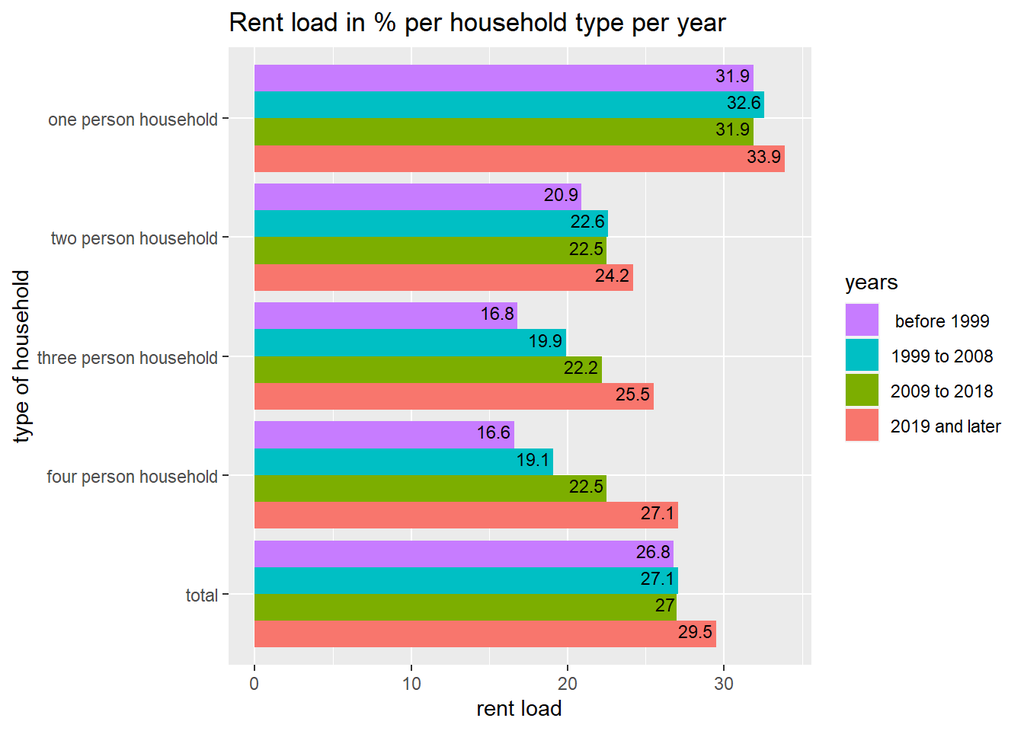

This graph visualizes for different household types and different years the average rent load as well as the average over all household types (here called “total”) over different years. As we can especially see in the difference of the orange bar compared to the other bars, the people in Germany are indeed paying more of their net income for their rent in 2019 and later than before — and not just a little bit. The total over all German households reveals that although rent prices were falling, the rent load rose from 26.8% before 1999 to 29.5% for 2019 and later. This is an increase of 2.7 percent points but a relative increase of over 10%. And this is only the total average situation. Especially for three-person and four-person households, the rent load increased significantly. While a four-person household had an average rent load of 16.6% before 1999, it now has to deal with a rent load of 27.1%. A relative increase of more than 60%.

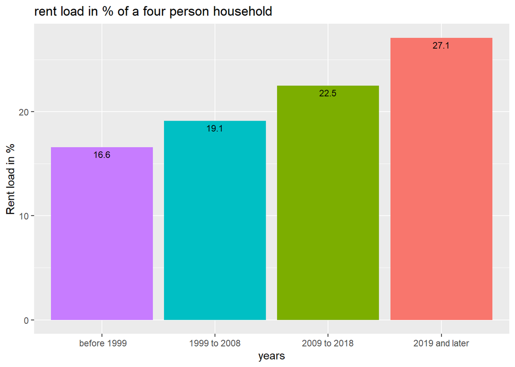

As we can see, the rent load for a four-person household steadily increased. This is against what we would expect from the data about the rent index and might explain why people in Germany complain about rising rents. Even though the rents are not growing, the portion of their salary they must pay is increasing.

If the rents are not rising but the portion of the wage used for rent increases, that could mean that real wages have fallen over time. The Federal Statistical Office collected data about the real wages (wages that consider inflation) in their dataset 62361-0020 that I visualized.

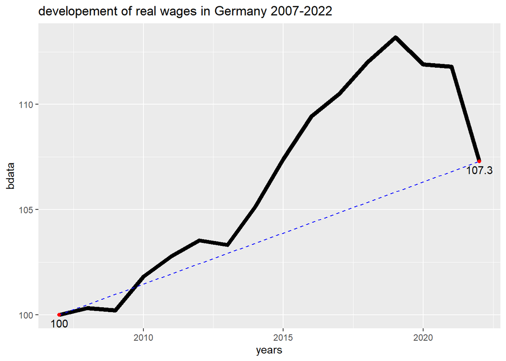

The collected data dates back only until 2007 and not until 1999, like the other data, but that should be fine for our purpose. (If any reader has a better dataset with a more extended history, please write me about it at leonoez@web.de).

I highlighted the start and end values for the real wages in the data. As we can see, the real wage index increased from 100 to 107.3, an increase of 7.3%. So, over the given time period, the real wages have increased. This holds true even though the data ends in 2022 (very quickly rising inflation in 2022 with very slowly rising wages led to a sudden decrease in real wages in 2022; this is expected to normalize again in 2023 and 2024).

We can, therefore, not conclude that the rise in rent load came from a decline in real wages. But from what else does it come?

### Potential Reasons

We saw that the rent load of German people rose, even though rents were falling and wages were rising. In the following paragraphs I want to go over some potential reasons that could be responsible for this.

**1. The rented space:** Until now we looked at the development of rents as in “how much more expensive did the same space get”. But people don’t always rent the same space. As society progresses, and living standards progress, people want better food, better clothing and of course also better flats. And better flats often mean bigger flats. The Federal Statistical office wrote in their [press release Nr. N041](https://www.destatis.de/DE/Presse/Pressemitteilungen/2023/06/PD23_N041_31.html) about German living standards and how they changed over the last decades. In this press release they also published data about the average living space per person in Germany over 30 years from 1991 to 2021. Visualizing this data we are able to see a clear trend.

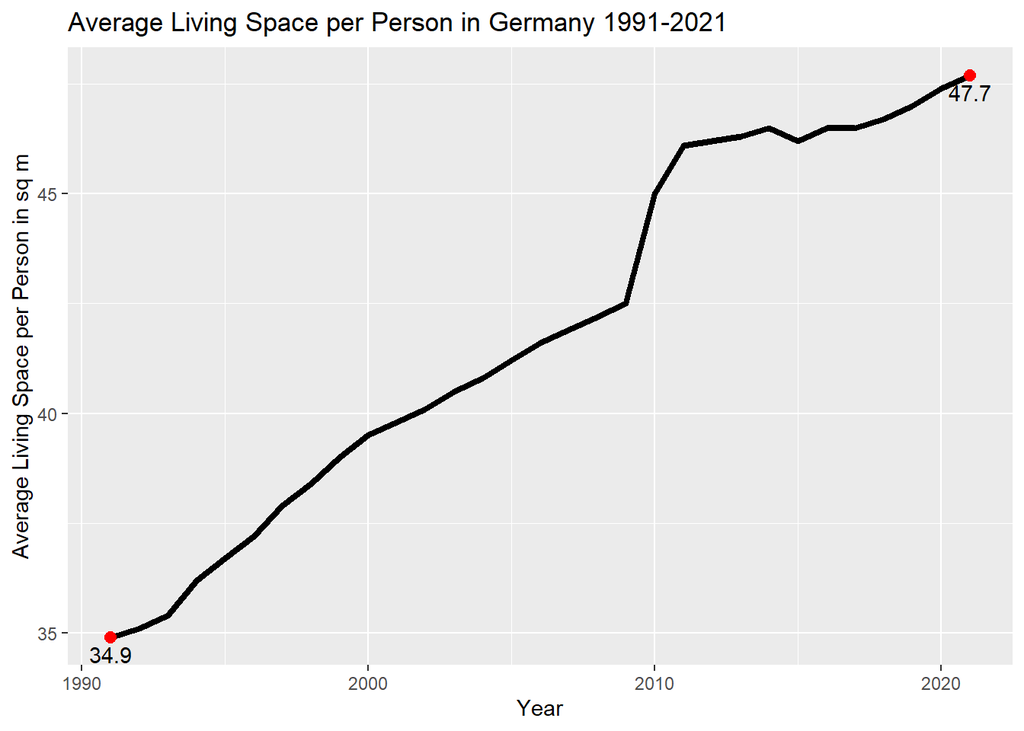

As we can see, the average space in square meters per person rose within this time from 34.9 square meters to 47.7 square meters . This is an increase of 36.7%. But this data starts in 1991 while the data about the rent index starts in 1995, to make it more comparable we should only use the data from 1995 onwards. The average living space per person in 1995 was 36.7 sq meters. Comparing this with the 47.7 square meters in 2021 will still results in a rise of the living space by 30%. When moving from one day to another in a 30% bigger flat we would all expect to pay more for this flat. But because the average living space rose so slowly over the last several decades that this is the new normal. And we still expect to pay as much as before.

And this is not just a social phenomenon. People who lose their job in Germany get what is called “Bürgergeld”. They get 568€ per month (in 2024) and additionally they get their entire rent payed. Under the condition that they are living in a flat that as an “appropriate” size and rent. Now what is appropriate for the German government to pay? For 2024 an appropriate flat size for a one-person household is between 45 and 50 square meters [[1](https://www.buerger-geld.org/news/buergergeld-wie-hoch-darf-die-miete-der-wohnung-sein/#Buergergeld_Wie_gross_darf_die_Wohnung_eines_Buergergeld_Beziehers_sein)]. This is exactly what we found out to be the german average living space per person.

So it might be, that even the German government sees this increased space as normal. So this is something that we as the entire country are responsible for.

But is this the only reason? Probably not. I think there are other (potentially correlated) developments in this country that influence the space that is needed.

**2. The household:** The type of household one lives in significantly determines the type of space one needs. A one-person household usually needs one or two rooms as well as a kitchen and a bathroom. A three-person household usually needs three to four rooms, but also just one kitchen and one bathroom. This decreases the space per person that is needed. The Federal Statistical Office collected data about the percentage of population living in a X-person household and I will try to explain the data in a visual way as easy to understand as possible. The first thing I want to show is the development of one-person and two-person households:

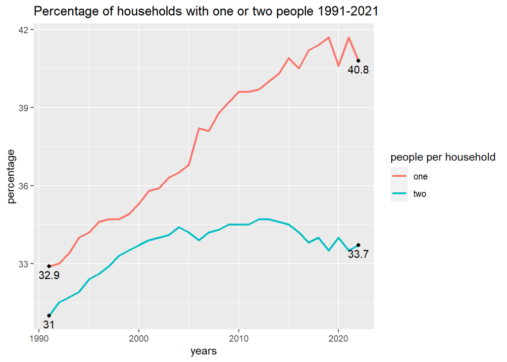

As we can see, both the number of one- and the number of two-person households increased. The number of two-person households increased until 2004 where it started to move mostly sideways for the rest of the time. The number of one-person households increased from 32.9% in 1991 to 40.8%. This is an increase of 7.9 percent points or a relative increase of 24%. But percentages have to add up to 100% so what was gained here was lost in the three-,four-,five- and more than five-people households as we can see below.

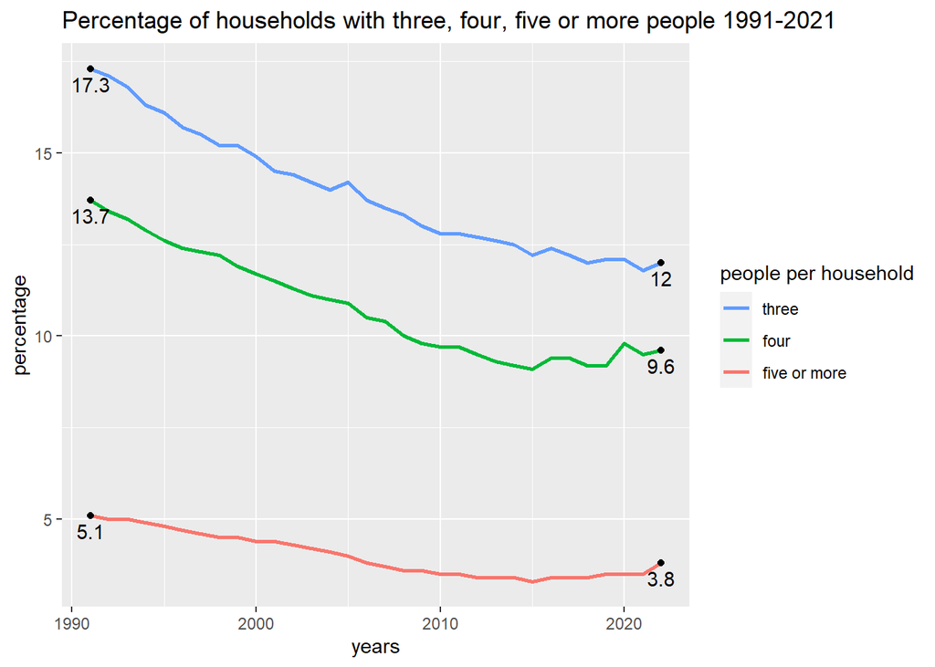

As we see, all of these household types became more and more underrepresented. Three-person households only make up 12 percent of the German households. A decease of 5.3 percent points and a relative decrease of 30.6% compared to 1991.

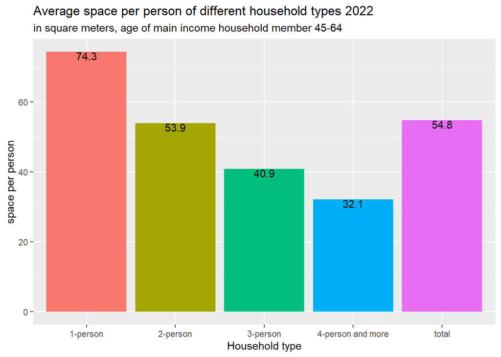

As we can see, the average space per person goes down with increasing household size. The average one-person household takes up more than double the amount of space per person compared to a four-or-more-person household and roughly 82% more than in a three person household. With differences that are so high, I think we should see the high increase of one-person households very critically. But I still think that this is not the entire reason. For now we just looked at one age group, but the used flat also depends on the different age groups and how they live, which brings us to our last section:

**3. demographic:** As most people already know, Germany has a demographical problem. The society is getting older and older on average which especially stresses the pension system[[3](https://www.bmas.de/DE/Soziales/Rente-und-Altersvorsorge/Fakten-zur-Rente/Alternde-Gesellschaft/alternde-gesellschaft.html),[4](https://www.bpb.de/themen/soziale-lage/rentenpolitik/291711/demografischer-wandel-und-rentenfinanzierung/)]. But while a lot of people know about the problems with the aging population and the pension system, most people don’t think about the problems the demographic change has for the rent market.

The age of a person heavily influences the space a person uses on average, and even though they don’t earn the most money, the age group of people age 65 and older (called 65+ in the following) lives in the biggest flats (on average). This influences the rent load and might be a reason for the problem we have seen in the first section of this Analysis that the rent load is rising.

Another problem is, that the people of the age group 65+ live especially often alone or in two-person households [[2](https://www.destatis.de/DE/Presse/Pressemitteilungen/2023/06/PD23_N035_12.html)]. Something we already saw in the section before to be more space consuming and therefore more expensive. Then why do they rent so big flats? According to a [press release](https://www.destatis.de/DE/Presse/Pressemitteilungen/2023/06/PD23_N035_12.html) of the Federal Statistical office in six out of ten cases they already live there for over 20 years and didn’t change their flats. I would suspect, that these people had different living situations 20 years earlier - Maybe children that moved out, maybe partners that died or left - and that moving to a different flat would be too expensive or too difficult, so they stay in a big flat.

But how much more space does the age group 65+ need?

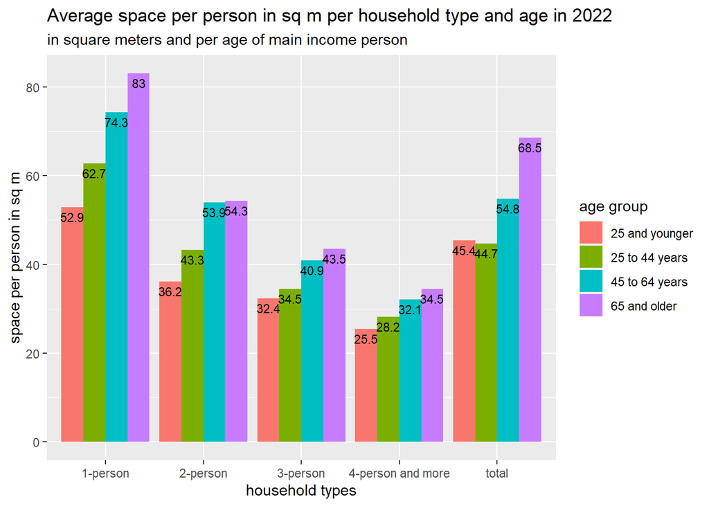

As we can see, throughout all of the household types, the age group 65+ (here purple) uses the most space per person. An average person of the age group 65+ uses more than 1.5 times as much space as an average person of the age group 25-44 years. Readers of the above written passage “1. the rented space” might remember that the average space per person in Germany rose from 34.9 square meters to 47.7 square meters. The average person in the 65+ age group has a living space of 68.5 square meters (43.6% more than the German average). The average one-person household in the 65+ age group has a living space per person of 83 square meters (74% more than the German average).

As we saw, the age group 65+ uses significantly more space than the younger age groups. Space that is lost for the market and could otherwise be used. And this is not only a problem here and now but especially as time progresses. In the year 1991 this age group made up roughly 15% of the German population[[5](https://www.destatis.de/DE/Themen/Querschnitt/Demografischer-Wandel/Aeltere-Menschen/bevoelkerung-ab-65-j.html)]. Nowadays it is approximately 22%. An increase in 7 percent points and a relative increase of more than 46%. And looking at the data it is still rising ([6](https://www.demografie-portal.de/DE/Fakten/aeltere-bevoelkerung.html?nn=676784), [7](https://www.bpb.de/kurz-knapp/zahlen-und-fakten/soziale-situation-in-deutschland/61541/bevoelkerungsentwicklung-und-altersstruktur/), [8](https://de.statista.com/statistik/daten/studie/196598/umfrage/prognose-des-anteils-der-bevoelkerung-ab-65-jahren-in-deutschland/), [9](https://www.destatis.de/DE/Presse/Pressemitteilungen/2022/12/PD22_511_124.html)).

## Conclusion

In this analysis, we looked at the numbers regarding the complaints of many Germans that rent prices were rising too high. Using Data from the Federal Statistical Office, we could show that rent prices, considering inflation, actually fell while the real wages of German people were increasing. But we could nonetheless show that the portion of income that German people have to spend on their rent, the rent load, increased. Reasons for this could be the general increase of space per person from 34.9 square meters to 47.7 square meters, but also the trend towards more space consuming one-person households and the demographic change in Germany.

Solutions for this could be trying to form a flat sharing community. Especially for the elderly this could be a potential chance as it combines several benefits together. Not only does the shared living decrease the rent load, it also helps with getting more social contact and through dividing housework also helps decreasing the physical load on everyone, as housework might get increasingly difficult with progressing age.

For other people I would suggest critically inspecting their space per person. How much space per person is used in your household? How much is needed? And how much is actually needed when looked at it a second time. Also I would suggest planning beforehand. Do you have changes in your household coming up? If you live with children, when will they likely move out? A lot of the people in the age group 65+ are already living in their flats for over 20 years, but at some point oneself might be to old, to weak or too poor to move. I wish that to no one. That is why I hope that after this analysis everyone knows what to look out for.

## Sources and Links

### Provided Sources

- [1] [Bürgergeld - Größe der Wohnung](https://www.buerger-geld.org/news/buergergeld-wie-hoch-darf-die-miete-der-wohnung-sein/#Buergergeld_Wie_gross_darf_die_Wohnung_eines_Buergergeld_Beziehers_sein)
- [2] [Statistisches Bundesamt - Pressemitteilung Nr. N 035](https://www.destatis.de/DE/Presse/Pressemitteilungen/2023/06/PD23_N035_12.html)
- [3] [Bundesministerium für Arbeit und Soziales - Alternde Gesellschaft](https://www.bmas.de/DE/Soziales/Rente-und-Altersvorsorge/Fakten-zur-Rente/Alternde-Gesellschaft/alternde-gesellschaft.html)
- [4] [Bundesministerium für Politische Bildung - Demografischer Wandel und Rentenfinanzierung](https://www.bpb.de/themen/soziale-lage/rentenpolitik/291711/demografischer-wandel-und-rentenfinanzierung/)
- [5] [Statistisches Bundesamt - Ältere Menschen](https://www.destatis.de/DE/Themen/Querschnitt/Demografischer-Wandel/Aeltere-Menschen/bevoelkerung-ab-65-j.html)
- [6] [Demografie Portal - Ältere Bevölkerung](https://www.demografie-portal.de/DE/Fakten/aeltere-bevoelkerung.html?nn=676784)
- [7] [Bundeszentrale für Politische Bildung - Bevölkerungsentwicklung und Altersstruktur](https://www.bpb.de/kurz-knapp/zahlen-und-fakten/soziale-situation-in-deutschland/61541/bevoelkerungsentwicklung-und-altersstruktur/)
- [8] [Statista - Prognose für den Anteil der Bevölkerung über 65 Jahren](https://de.statista.com/statistik/daten/studie/196598/umfrage/prognose-des-anteils-der-bevoelkerung-ab-65-jahren-in-deutschland/)
- [9] [Statistisches Bundesamt - Ältere Bevölkerung ab 2035](https://www.destatis.de/DE/Presse/Pressemitteilungen/2022/12/PD22_511_124.html)

### Collection of Links from the Texts

1. [Statistisches Bundesamt - Pressemitteilung Nr. N041](https://www.destatis.de/DE/Presse/Pressemitteilungen/2023/06/PD23_N041_31.html)
2. [Statistisches Bundesamt - Pressemitteilung Nr. N 035](https://www.destatis.de/DE/Presse/Pressemitteilungen/2023/06/PD23_N035_12.html)

### Collection of Data Sources

1. Rent Data:
- [Statistisches Bundesamt - Verbraucherpreisindex - Dataset 61111-0003 - Code CC13-041](https://www-genesis.destatis.de/datenbank/beta/table/61111-0003)
- [Statista - Entwicklung des Wohnungsmietindex für Deutschland in den Jahren von 1995 bis 2022](https://de.statista.com/statistik/daten/studie/70132/umfrage/mietindex-fuer-deutschland-1995-bis-2007/)
2. Inflation Data:
- [Statistisches Bundesamt - Data set 61111-0001](https://www-genesis.destatis.de/datenbank/beta/table/61111-0001)
3. Rent-load:
- [Statistisches Bundesamt - Mieten, Mietbelastung, Haushaltsgröße und Einzugsjahr](https://www.destatis.de/DE/Themen/Gesellschaft-Umwelt/Wohnen/Tabellen/tabelle-wo7-mieten-einzugsjahr.html)
4. Real wages:
- [Statistisches Bundesamt - Reallohnindex, Nominallohnindex: Deutschland, Jahre](https://www-genesis.destatis.de/datenbank/beta/table/62361-0020)
5. Space per person:
- [Statistisches Bundesamt - Pressemitteilung Nr. N041 - 29.06.2023](https://www.destatis.de/DE/Presse/Pressemitteilungen/2023/06/PD23_N041_31.html)
6. Household Data:
- [Statistisches Bundesamt - Haushalte nach Haushaltsgrößen im Zeitvergleich](https://www.destatis.de/DE/Themen/Gesellschaft-Umwelt/Bevoelkerung/Haushalte-Familien/Tabellen/1-3-privathaushalte-neuer-zeitvergleich.html)
7. Space per person in different age groups:
- [Statistisches Bundesamt - Pressemitteilung Nr. N 035 - 14.06.2023](https://www.destatis.de/DE/Presse/Pressemitteilungen/2023/06/PD23_N035_12.html)